# DA5020 – Practicum I

```r
library(lubridate)
library(tidyverse)
library(ggrepel)
library(scales)
library(XML)
```

2. (15 pts) Load the data into R (directly from the URL) and create two linked tibbles: one for country and the other for covid_19_data that contains each country’s reported case. The country tibble should contain the following: countriesAndTerritories, countryterritoryCode (primary key), popData2018, continentExp. The covid_19_data tibble should contain: id (auto incremented value that will serve as the primary key), countryterritoryCode(foreign key), dateRep, cases, deaths. You can link/join both tibbles by using the countryterritoryCode.

```r
xml_doc <- readLines("https://opendata.ecdc.europa.eu/covid19/casedistribution/xml/",
                     encoding = "UTF-8")
```

```
incomplete final line found on 'https://opendata.ecdc.europa.eu/covid19/casedistribution/xml/'
```

```r
covid_19 <- as_tibble(xmlToDataFrame(xml_doc, stringsAsFactors = FALSE))
glimpse(covid_19)
```

```
Rows: 23,219
Columns: 11
$ dateRep                 <chr> "13/06/2020", "12/06/2020", "11/06/2020", "10/06/2020", "09/06/2020", "08/06/2020", "07/06/2020"...
$ day                     <chr> "13", "12", "11", "10", "9", "8", "7", "6", "5", "4", "3", "2", "1", "31", "30", "29", "28", "27...
$ month                   <chr> "6", "6", "6", "6", "6", "6", "6", "6", "6", "6", "6", "6", "6", "5", "5", "5", "5", "5", "5", "...
$ year                    <chr> "2020", "2020", "2020", "2020", "2020", "2020", "2020", "2020", "2020", "2020", "2020", "2020", ...
$ cases                   <chr> "656", "747", "684", "542", "575", "791", "582", "915", "787", "758", "759", "545", "680", "866"...
$ deaths                  <chr> "20", "21", "21", "15", "12", "30", "18", "9", "6", "24", "5", "8", "8", "3", "11", "8", "7", "1...
$ countriesAndTerritories <chr> "Afghanistan", "Afghanistan", "Afghanistan", "Afghanistan", "Afghanistan", "Afghanistan", "Afgha...
$ geoId                   <chr> "AF", "AF", "AF", "AF", "AF", "AF", "AF", "AF", "AF", "AF", "AF", "AF", "AF", "AF", "AF", "AF", ...
$ countryterritoryCode    <chr> "AFG", "AFG", "AFG", "AFG", "AFG", "AFG", "AFG", "AFG", "AFG", "AFG", "AFG", "AFG", "AFG", "AFG"...
$ popData2018             <chr> "37172386", "37172386", "37172386", "37172386", "37172386", "37172386", "37172386", "37172386", ...
$ continentExp            <chr> "Asia", "Asia", "Asia", "Asia", "Asia", "Asia", "Asia", "Asia", "Asia", "Asia", "Asia", "Asia", ...
```

```r
## fix data types
covid_19 <- covid_19 %>%
  mutate(dateRep = dmy(dateRep)) %>%
  mutate_at(vars("day", "month", "year", "cases","deaths", "popData2018"),
            as.integer)
covid_19
```

| dateRep | day | month | year | cases | deaths | countriesAndTerritories | geoId | countryterritoryCode | popData2018 | continentExp |
| --- | --- | --- | --- | --- | --- | --- | --- | --- | --- | --- |
| 2020-06-13 | 13 | 6 | 2020 | 656 | 20 | Afghanistan | AF | AFG | 37172386 | Asia |
| 2020-06-12 | 12 | 6 | 2020 | 747 | 21 | Afghanistan | AF | AFG | 37172386 | Asia |
| 2020-06-11 | 11 | 6 | 2020 | 684 | 21 | Afghanistan | AF | AFG | 37172386 | Asia |
| 2020-06-10 | 10 | 6 | 2020 | 542 | 15 | Afghanistan | AF | AFG | 37172386 | Asia |
| 2020-06-09 | 9 | 6 | 2020 | 575 | 12 | Afghanistan | AF | AFG | 37172386 | Asia |
| 2020-06-08 | 8 | 6 | 2020 | 791 | 30 | Afghanistan | AF | AFG | 37172386 | Asia |
| 2020-06-07 | 7 | 6 | 2020 | 582 | 18 | Afghanistan | AF | AFG | 37172386 | Asia |
| 2020-06-06 | 6 | 6 | 2020 | 915 | 9 | Afghanistan | AF | AFG | 37172386 | Asia |
| 2020-06-05 | 5 | 6 | 2020 | 787 | 6 | Afghanistan | AF | AFG | 37172386 | Asia |
| 2020-06-04 | 4 | 6 | 2020 | 758 | 24 | Afghanistan | AF | AFG | 37172386 | Asia |

[output cut: 990 more lines]

```r
## country table
country <- covid_19 %>% select(countriesAndTerritories,
                               countryterritoryCode,
                               popData2018,
                               continentExp)

## case data table
covid_19_data <- covid_19 %>% select(countryterritoryCode,
                                     dateRep,
                                     cases,
                                     deaths)
## generate IDs
covid_19_data <- covid_19_data %>%
  mutate(ID = row_number())

country
```

| countriesAndTerritories | countryterritoryCode | popData2018 | continentExp |
| --- | --- | --- | --- |
| Afghanistan | AFG | 37172386 | Asia |
| Afghanistan | AFG | 37172386 | Asia |
| Afghanistan | AFG | 37172386 | Asia |
| Afghanistan | AFG | 37172386 | Asia |
| Afghanistan | AFG | 37172386 | Asia |
| Afghanistan | AFG | 37172386 | Asia |
| Afghanistan | AFG | 37172386 | Asia |
| Afghanistan | AFG | 37172386 | Asia |
| Afghanistan | AFG | 37172386 | Asia |
| Afghanistan | AFG | 37172386 | Asia |

[output cut: 990 more lines]

```r
covid_19_data
```

| countryterritoryCode | dateRep | cases | deaths | ID |
| --- | --- | --- | --- | --- |
| AFG | 2020-06-13 | 656 | 20 | 1 |
| AFG | 2020-06-12 | 747 | 21 | 2 |
| AFG | 2020-06-11 | 684 | 21 | 3 |
| AFG | 2020-06-10 | 542 | 15 | 4 |
| AFG | 2020-06-09 | 575 | 12 | 5 |
| AFG | 2020-06-08 | 791 | 30 | 6 |
| AFG | 2020-06-07 | 582 | 18 | 7 |
| AFG | 2020-06-06 | 915 | 9 | 8 |
| AFG | 2020-06-05 | 787 | 6 | 9 |
| AFG | 2020-06-04 | 758 | 24 | 10 |

[output cut: 990 more lines]

```r
## rejoin if needed
left_join(country, covid_19_data)
```

| countriesAndTerritories | countryterritoryCode | popData2018 | continentExp | dateRep | cases | deaths | ID |
| --- | --- | --- | --- | --- | --- | --- | --- |
| Afghanistan | AFG | 37172386 | Asia | 2020-06-13 | 656 | 20 | 1 |
| Afghanistan | AFG | 37172386 | Asia | 2020-06-12 | 747 | 21 | 2 |
| Afghanistan | AFG | 37172386 | Asia | 2020-06-11 | 684 | 21 | 3 |
| Afghanistan | AFG | 37172386 | Asia | 2020-06-10 | 542 | 15 | 4 |
| Afghanistan | AFG | 37172386 | Asia | 2020-06-09 | 575 | 12 | 5 |
| Afghanistan | AFG | 37172386 | Asia | 2020-06-08 | 791 | 30 | 6 |
| Afghanistan | AFG | 37172386 | Asia | 2020-06-07 | 582 | 18 | 7 |
| Afghanistan | AFG | 37172386 | Asia | 2020-06-06 | 915 | 9 | 8 |
| Afghanistan | AFG | 37172386 | Asia | 2020-06-05 | 787 | 6 | 9 |
| Afghanistan | AFG | 37172386 | Asia | 2020-06-04 | 758 | 24 | 10 |

[output cut: 990 more lines]

3.(10 pts) Create a function called worldwideCases() that displays: a) the total cases worldwide, b) the number of new cases within the past day (grouped by continent).

```r
worldwideCases <- function() {
  total_cases <- covid_19_data %>%
    pull(cases) %>%                            ## grab case numbers
    sum() %>%                                  ## sum
    comma()                                    ## format

  continent_data <-
    covid_19 %>%                               ## merge tables
    group_by(continentExp) %>%                 ## group continents
    filter(dateRep == max(dateRep)) %>%        ## get cases for the latest date entry
    summarise(cases_today = sum(cases))        ## summarise by continent

  print(continent_data)
  print(str_c("Total world-wide cases: ", total_cases))
}
worldwideCases()
```

| continentExp | cases_today |
| --- | --- |
| Africa | 8621 |
| America | 79303 |
| Asia | 38380 |
| Europe | 17758 |
| Oceania | 8 |
| Other | -9 |

```
[1] "Total world-wide cases: 7,625,883"
```

4.(10 pts) Create visualizations that show the progression of the cases and the mortality rate in each continent.

**We will look at weekly cases because monthly may be too little resolution, and daily may be too high resolution introducing too much noise.**

```r
covid_weeks <-
  covid_19 %>%
    mutate(week = week(dateRep)) %>%              ## get week numbers
  group_by_at(vars("continentExp", "week")) %>%
  mutate(death_week_continent = sum(deaths),
         case_week_continent = sum(cases)) %>%    ## calculate deaths & cases / week / continent
  select(dateRep,
         week,
         continentExp,
         death_week_continent,
         case_week_continent) %>%
  slice(n())                                      ## get the earliest date entry for the week

covid_weeks
```

| dateRep | week | continentExp | death_week_continent | case_week_continent |
| --- | --- | --- | --- | --- |
| 2020-01-01 | 1 | Africa | 0 | 0 |
| 2020-01-08 | 2 | Africa | 0 | 0 |
| 2020-01-15 | 3 | Africa | 0 | 0 |
| 2020-01-22 | 4 | Africa | 0 | 0 |
| 2020-01-29 | 5 | Africa | 0 | 0 |
| 2020-02-05 | 6 | Africa | 0 | 0 |
| 2020-02-12 | 7 | Africa | 0 | 1 |
| 2020-02-19 | 8 | Africa | 0 | 0 |
| 2020-03-03 | 9 | Africa | 0 | 8 |
| 2020-03-10 | 10 | Africa | 1 | 86 |

[output cut: 126 more lines]

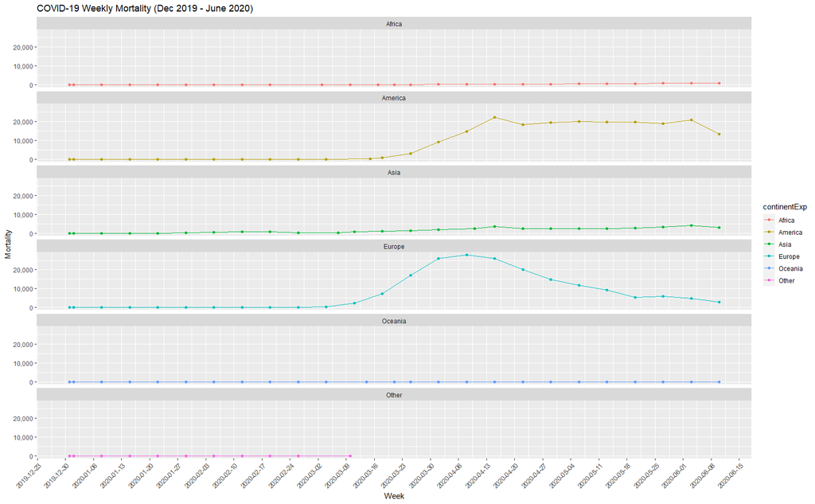

```r
## function to plot weekly mortality or cases
  plot_fn <- function(y, z) {                  ## inputs to plot feature and label
    ggplot(data = covid_weeks, aes(
    x = dateRep,
    y = get(y),
    color = continentExp,
    group = continentExp)) +
  geom_point() +
  geom_line() +
  facet_wrap(~continentExp, ncol = 1) +
  scale_x_date(breaks = "weeks") +
  theme(axis.text.x = element_text(angle = 45, hjust = 1)) +
  labs(title = str_c("COVID-19 Weekly ", z," (Dec 2019 - ",
                     months(today()), " ", year(today()), ")"),
       x     = "Week",
       y     = z) +
      scale_y_continuous(labels = comma)
  }

 plot_fn("death_week_continent", "Mortality")  ## plot weekly deaths by continent
```

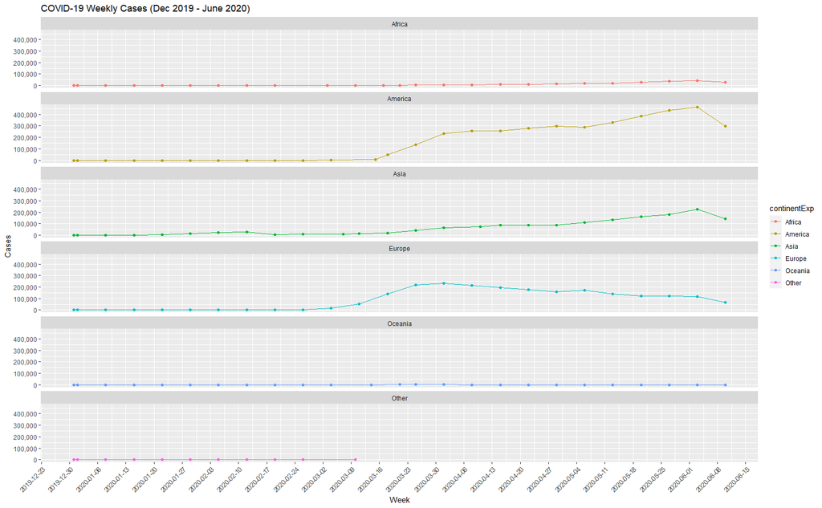

```r
 plot_fn("case_week_continent", "Cases")       ## plot weekly cases by continent
```

5. (10 pts) Display the ten countries with the highest number of cases. Analyze the data and indicate the date of the first reported case and the ratio of cases-to-fatalities for each country (use supporting visualizations).

```r
country_totals <-
  covid_19 %>%
    group_by(countriesAndTerritories) %>%                              ## group by country
    mutate(cumulative_cases    = sum(cases),
           cumulative_deaths   = sum(deaths),
           cases_to_fatalities = cumulative_cases / cumulative_deaths) %>%   ## calculate total cases, total fatalities, and cases / fatality
  filter(cases > 0) %>% slice(n()) %>%                                 ## last row == first chronological entry where cases > 0
  rename(first_reported = dateRep) %>%                                 ## rename appropriately
    ungroup() %>% arrange(desc(cumulative_cases)) %>%                  ## arrange by total cases descending
    select(countriesAndTerritories,
           cumulative_cases,
           cumulative_deaths,
           cases_to_fatalities,
           first_reported) %>%                                         ## subset information needed for this exercise
    distinct()

country_totals %>% top_n(10, cumulative_cases)                         ## grab top 10 cases and first reported cases
```

| countriesAndTerritories | cumulative_cases | cumulative_deaths | cases_to_fatalities | first_reported |
| --- | --- | --- | --- | --- |
| United_States_of_America | 2048986 | 114669 | 17.868700 | 2020-01-21 |
| Brazil | 828810 | 41828 | 19.814717 | 2020-02-26 |
| Russia | 511423 | 6715 | 76.161281 | 2020-02-01 |
| India | 308993 | 8884 | 34.780842 | 2020-01-30 |
| United_Kingdom | 292950 | 41481 | 7.062269 | 2020-01-31 |
| Spain | 243209 | 27136 | 8.962596 | 2020-02-01 |
| Italy | 236305 | 34223 | 6.904859 | 2020-01-31 |
| Peru | 220749 | 6308 | 34.995086 | 2020-03-07 |
| Germany | 186022 | 8781 | 21.184603 | 2020-01-28 |
| Iran | 182545 | 8659 | 21.081534 | 2020-02-20 |

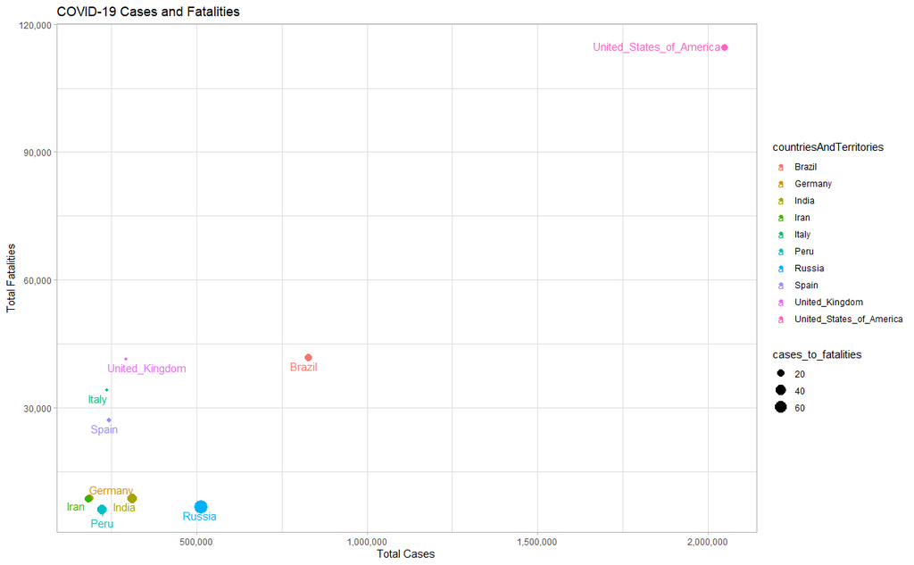

```r
ggplot(data = country_totals %>% top_n(10, cumulative_cases),
       aes(x     = cumulative_cases,
           y     = cumulative_deaths,
           color = countriesAndTerritories,
           size  = cases_to_fatalities)) +
  geom_point() +
  # geom_text(aes(                                                    ## uncomment if needed
  #   label = countriesAndTerritories),
  #   size  = 4,
  #   hjust = 0,
  #   vjust = 0) +
  ## ggrepel::geom_text_repel() is used to prevent overlapping labels. ggplot2::geom_text() is also sufficient
  geom_text_repel(aes(
    label = countriesAndTerritories),
    size  = 4,
    hjust = 0,
    vjust = 0) +
  labs(title = "COVID-19 Cases and Fatalities",
       x     = "Total Cases",
       y     = "Total Fatalities") +
  scale_x_continuous(labels = comma) +
  scale_y_continuous(labels = comma) +
  theme_light()
```

6. (10 pts) Use the mutate verb in dplyr to calculate the cumulative cases and deaths for each country. The new fields should be named cumulative_cases and cumulative_deaths respectively.

```r
## calculated in Question 5

country_totals
```

| countriesAndTerritories | cumulative_cases | cumulative_deaths | cases_to_fatalities | first_reported |
| --- | --- | --- | --- | --- |
| United_States_of_America | 2048986 | 114669 | 17.868700 | 2020-01-21 |
| Brazil | 828810 | 41828 | 19.814717 | 2020-02-26 |
| Russia | 511423 | 6715 | 76.161281 | 2020-02-01 |
| India | 308993 | 8884 | 34.780842 | 2020-01-30 |
| United_Kingdom | 292950 | 41481 | 7.062269 | 2020-01-31 |
| Spain | 243209 | 27136 | 8.962596 | 2020-02-01 |
| Italy | 236305 | 34223 | 6.904859 | 2020-01-31 |
| Peru | 220749 | 6308 | 34.995086 | 2020-03-07 |
| Germany | 186022 | 8781 | 21.184603 | 2020-01-28 |
| Iran | 182545 | 8659 | 21.081534 | 2020-02-20 |

[output cut: 200 more lines]

7. (15 pts) Create a function called, casesByCountry(), that takes a user defined date and country code as its arguments and displays the distribution of cases for the selected country, leading up to the chosen date. Annotate the chart to show the highest number of cases that were reported; this should correspond with the daily reported case and not the cumulative cases. The chart should also contain a subtitle that indicates the population for the selected country. Note: if a date is not specified, make the current date the default. If a country is not specified, display a message to the user.

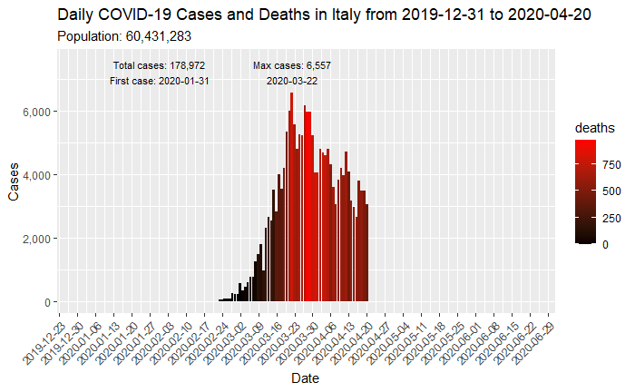

```r
casesByCountry <- function(x = 1, y = 1) {
  ## use the latest available date if none is supplied
  ## today if the data is current. yesterday if it's not
  if (y == 1) {
    y <- covid_19 %>%
      pull(dateRep) %>%
      max()
  }

  ## print a message and pick a random country if no country is supplied
  if(x == 1) {
    x <- covid_19 %>%
      distinct(countriesAndTerritories) %>%
      pull() %>%
      sample(1)
    print(str_c(
      "No country specified. Showing a random country instead: how about ", x, "?"
    ))
  }

  ## not required for this exercise, but would be useful:
  ## search by country names instead of country code if desired since names are more commonly known than codes
  ## also make it case / space insensitive, i.e. "new zealand" == "New_Zealand"
  if (nchar(x) > 3) { ## country codes do not exceed 3 characters

    if (x %in% covid_19$countriesAndTerritories) {

      ## find matching rows with exact country name
      country_name <- x
      row_query <- grep(country_name,
                        covid_19$countriesAndTerritories,
                        ignore.case = FALSE)
    } else {
      ## find matching rows with approximate country name
      row_matches <- grep(gsub(" ", "_", x),
                        covid_19$countriesAndTerritories,
                        ignore.case = TRUE)

      ## use the first country if there are multiple matches
      country_name <-
        covid_19 %>% filter(
          row_number() %in% row_matches) %>%
        distinct(countriesAndTerritories) %>%
        slice(1) %>%
        pull()

      ## find matching rows with exact country name
      row_query <- grep(gsub(" ", "_", country_name),
                        covid_19$countriesAndTerritories,
                        ignore.case = TRUE)
    }

  } else {
    row_query <- grep(x,
                      covid_19$countryterritoryCode,
                      ignore.case = FALSE)

    country_name <-
      covid_19 %>% filter(
        row_number() %in% row_query) %>%
      distinct(countriesAndTerritories) %>%
      pull()
  }


  ## x-coordinate to plot annotation
  max_case_x <-
    covid_19 %>% filter(
      row_number() %in% row_query,
      dateRep <= y) %>%
    filter(cases == max(cases)) %>%
    pull(dateRep)

  ## y-coordinate to plot annotation
  max_case_y <-
    covid_19 %>% filter(
      row_number() %in% row_query,
      dateRep <= y) %>%
    pull(cases) %>% max()

  ## date of max daily cases
  max_case_date <-
    covid_19 %>% filter(
    row_number() %in% row_query,
    dateRep <= y) %>%
    filter(cases == max(cases)) %>%
    pull(dateRep)

  ############## needed for question 8 ##############

  ## first case date
  first_case_date <- covid_19 %>%
  filter(row_number() %in% row_query,
         dateRep <= y,
         cases >= 1) %>%
  pull(dateRep) %>%
  min()

  ## total cases
  total_cases <- covid_19 %>%
  filter(row_number() %in% row_query,
         dateRep <= y) %>%
  pull(cases) %>%
  sum()
  ##################################################

  ## population of selected country
  country_pop <-
    covid_19 %>%
    filter(row_number() %in% row_query) %>%
    pull(popData2018) %>%
    unique()

  ## filter table and plot
  covid_19 %>% filter(row_number() %in% row_query,
                      dateRep <= y) %>%
    ggplot(aes(x    = dateRep,
               y    = cases,
               fill = deaths)) +
    geom_col() +
    scale_x_date(breaks = "weeks",
                 limits = c(min(covid_19$dateRep), max(covid_19$dateRep) + days(10))) +
    scale_y_continuous(labels = comma,
                       limits = c(0, max_case_y + 0.15 * max_case_y)) +

    ## max case annotation
    annotate("text",
             x      = max_case_x,
             y      = max_case_y + 0.1 * max_case_y,
             colour = "black",
             size   = 3,
             label  = str_c("Max cases: ", comma(max_case_y),
                            "\n", max_case_date)) +

    ## total cases and first case date annotation (Question 8)
    annotate("text",
             x = first_case_date,
             y      = max_case_y + 0.1 * max_case_y,
             colour = "black",
             size   = 3,
             label  = str_c("Total cases: ", comma(total_cases),
                           "\n", "First case: ", first_case_date)) +
    theme(axis.text.x = element_text(angle = 45, hjust = 1)) +
    labs(
      title    = str_c("Daily COVID-19 Cases and Deaths in ", country_name,
                       " from ", min(covid_19$dateRep), " to ", y),
      subtitle = str_c("Population: ", comma(country_pop)),
      x        = "Date",
      y        = "Cases"
    ) +
    scale_fill_gradient(low = "black", high = "red")
}
## specify country & date "YYYY-MM-DD"
casesByCountry("ITA", "2020-04-20")
```

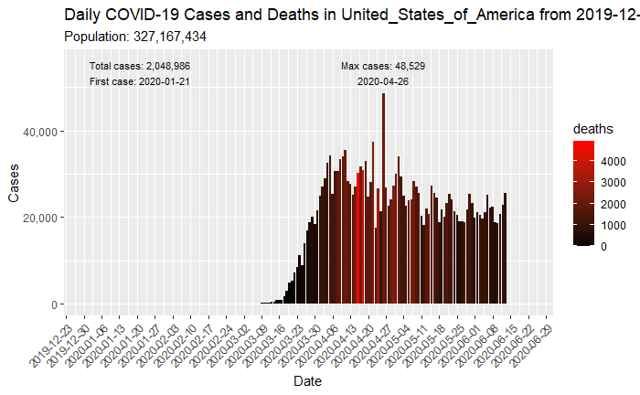

```r
## specify country only
casesByCountry("USA")
```

```
[1] "No country specified. Showing a random country instead: how about Iran?"
```

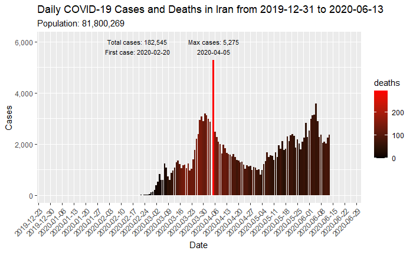

```r
## specify neither
casesByCountry()
```

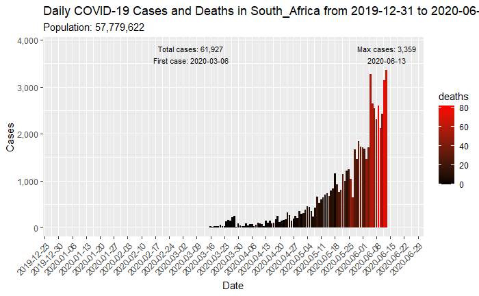

```r
## by country name
casesByCountry("south africa")
```

8.(30 pts) Select a country, of your choice, and use the casesByCountry() function to show the progression of the total COVID-19 cases to-date. Analyze the chart and the supporting data; indicate the total number of cases that were reported and the date of the first reported case. What is the current trend?

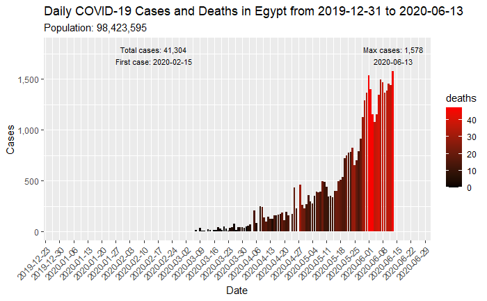

```r
casesByCountry("egypt")
```

**The current trend show that daily cases in Egypt are currently at their highest levels.**  
Based on your analysis for this country, what are the potential impact on countries like Andorra and San Marino. Create visualizations to support your analysis and/or add other supporting dataset(s) if necessary.

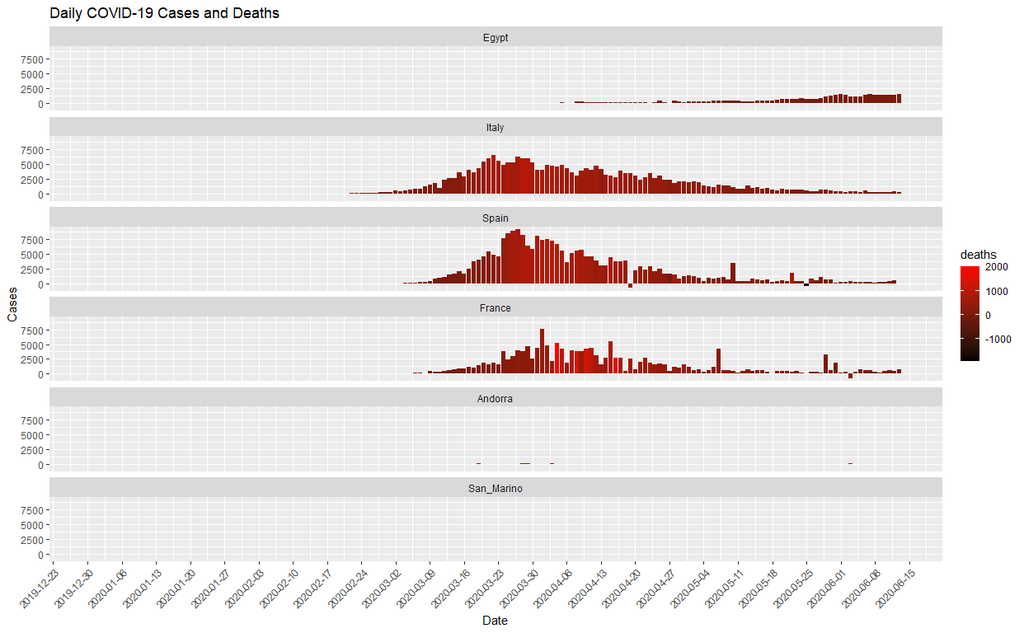

```r
covid_19 %>%
  filter(countriesAndTerritories %in% c("Egypt", "Italy", "Spain", "France", "Andorra", "San_Marino")) %>%
  ggplot(aes(x    = dateRep,
             y    = cases,
             fill = deaths)) +
  geom_col() +
  scale_x_date(breaks = "weeks") +
  facet_wrap(~factor(countriesAndTerritories,
                     levels = c("Egypt", "Italy", "Spain", "France", "Andorra", "San_Marino")), ncol = 1) +
  theme(axis.text.x = element_text(angle = 45, hjust = 1)) +
  scale_fill_gradient(low = "black", high = "red") +
  labs(title = "Daily COVID-19 Cases and Deaths",
       x = "Date",
       y = "Cases")
```

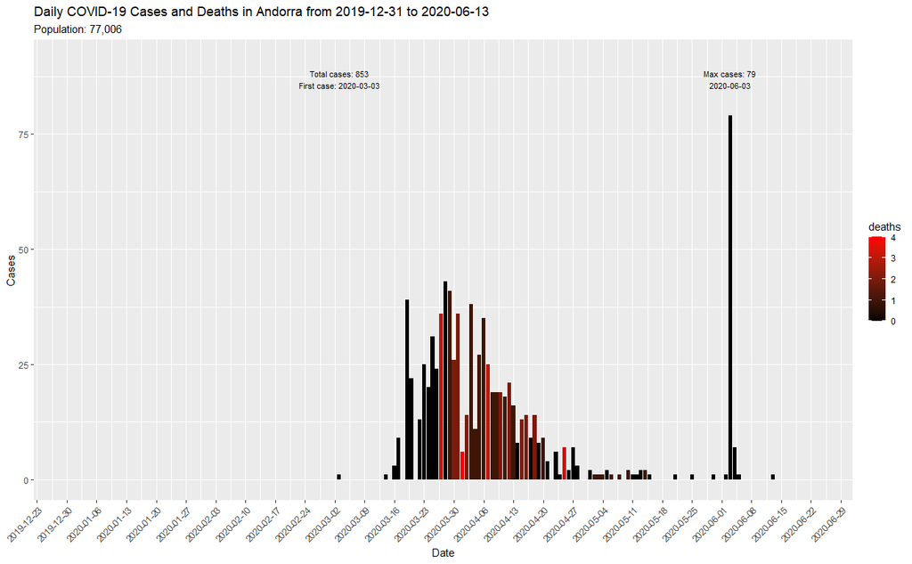

```r
casesByCountry("andorra")
```

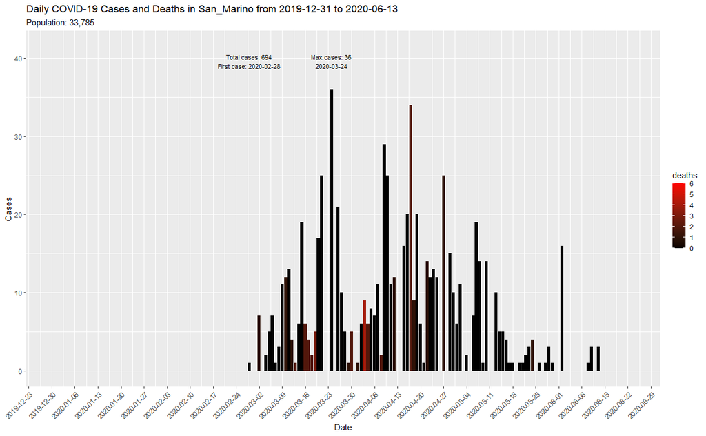

```r
casesByCountry("san marino")
```

**The cases trend in Egypt provide no meaningful insights regarding cases in San Marino and Andorra. The cases in San Marino and Andorra also appear to have passed their peaks (apart from a potential outlier in Andorra on 2020-06-03) and are on the decline, in stark contrast to Egypt. While neighboring countries of Italy, Spain, and France are among the most drastically impacted countries in Europe, the spread to Andorra and San Marino appear to be minimal.**